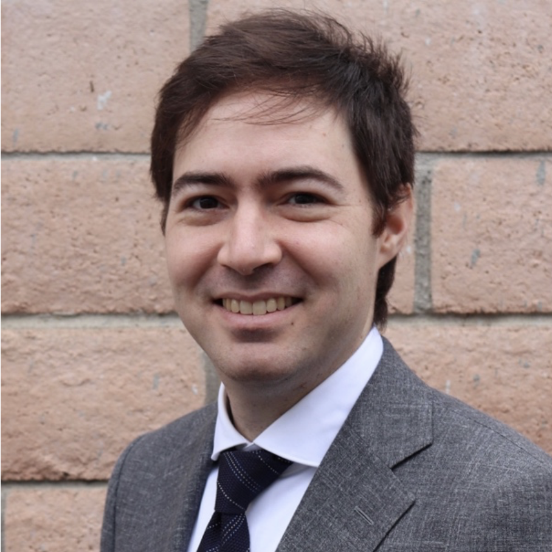

# Victor Gandarillas

Victor is a Ph.D. Candidate in the Large-Scale Design Optimization Lab at the University of California San Diego (UCSD). His primary focus lies in the application of Multidisciplinary Design Optimization (MDO) to spacecraft swarm mission design. Victor’s research interests go beyond mission design itself, encompassing the development of innovative methodologies and software tools. Notably, he created and actively leads the development of the Computational System Design Language (CSDL), which provides a platform for automating processes such as model code complexity analysis and sensitivity analysis. In addition to his ongoing research, Victor holds a Master’s degree in Mechanical and Aerospace Engineering from UCSD in which he developed a distributed multi-agent coverage control algorithm for autonomous robots. Prior to his graduate studies, Victor was an aeronautical engineer in the Lockheed Martin F-35 flight test program at Patuxent River Naval Air Station, MD. Prior to graduating with a B.S. in Aeronautics and Astronautics from Purdue University, Victor was also a cooperative education student at NASA Armstrong Flight Research Center and Caltech Summer Undergraduate Research Fellow at JPL. Looking ahead, Victor is eager to explore opportunities to enable rapid generation and exploration of space mission designs using MDO.